# CA04_Spring403

## Goal

In this notebook we learn about different machine learning models and how to train them and try To predict housing prices

## Problem Description

In this problem we will learn about basics of machine learning and different models in order to predict housing prices. I will check the questions and the code of that section for each section

### 1. Familiarity with the data set

at the first, i'm going to read the datas from the xlsx file given and store them

```python
import pandas as pd

df = pd.read_excel('DataSet.xlsx')
df.head(15)
```

|  | CRIM | ZN | INDUS | CHAS | NOX | RM | AGE | DIS | RAD | TAX | PTRATIO | B | LSTAT | MEDV |
| --- | --- | --- | --- | --- | --- | --- | --- | --- | --- | --- | --- | --- | --- | --- |
| 0 | 0.00632 | 18.0 | 2.31 | 0.0 | 0.538 | 6.575 | 65.2 | 4.0900 | 1 | 296.0 | 15.3 | 396.90 | 4.98 | 24.0 |
| 1 | 0.02731 | 0.0 | 7.07 | 0.0 | 0.469 | 6.421 | 78.9 | 4.9671 | 2 | 242.0 | 17.8 | 396.90 | 9.14 | 21.6 |
| 2 | 0.02729 | 0.0 | 7.07 | 0.0 | 0.469 | 7.185 | 61.1 | 4.9671 | 2 | 242.0 | 17.8 | 392.83 | 4.03 | 34.7 |
| 3 | 0.03237 | 0.0 | 2.18 | 0.0 | 0.458 | 6.998 | 45.8 | 6.0622 | 3 | 222.0 | 18.7 | NaN | 2.94 | 33.4 |
| 4 | 0.06905 | 0.0 | 2.18 | 0.0 | 0.458 | 7.147 | 54.2 | 6.0622 | 3 | 222.0 | 18.7 | 396.90 | 5.33 | 36.2 |
| 5 | 0.02985 | 0.0 | 2.18 | 0.0 | 0.458 | 6.430 | 58.7 | 6.0622 | 3 | 222.0 | 18.7 | 394.12 | 5.21 | 28.7 |
| 6 | 0.08829 | 12.5 | 7.87 | 0.0 | 0.524 | 6.012 | 66.6 | 5.5605 | 5 | 311.0 | 15.2 | 395.60 | 12.43 | 22.9 |
| 7 | 0.14455 | 12.5 | 7.87 | 0.0 | 0.524 | 6.172 | 96.1 | 5.9505 | 5 | 311.0 | 15.2 | 396.90 | 19.15 | 27.1 |
| 8 | 0.21124 | 12.5 | 7.87 | 0.0 | 0.524 | 5.631 | 100.0 | 6.0821 | 5 | 311.0 | 15.2 | 386.63 | 29.93 | 16.5 |
| 9 | 0.17004 | 12.5 | 7.87 | 0.0 | 0.524 | 6.004 | 85.9 | 6.5921 | 5 | 311.0 | 15.2 | 386.71 | 17.10 | 18.9 |
| 10 | 0.22489 | 12.5 | 7.87 | 0.0 | 0.524 | 6.377 | 94.3 | 6.3467 | 5 | 311.0 | 15.2 | 392.52 | 20.45 | 15.0 |
| 11 | 0.11747 | 12.5 | 7.87 | 0.0 | 0.524 | 6.009 | 82.9 | 6.2267 | 5 | 311.0 | 15.2 | 396.90 | 13.27 | 18.9 |
| 12 | 0.09378 | 12.5 | 7.87 | 0.0 | 0.524 | 5.889 | 39.0 | 5.4509 | 5 | 311.0 | 15.2 | 390.50 | 15.71 | 21.7 |
| 13 | 0.62976 | 0.0 | 8.14 | 0.0 | 0.538 | 5.949 | 61.8 | 4.7075 | 4 | 307.0 | 21.0 | 396.90 | 8.26 | 20.4 |
| 14 | 0.63796 | 0.0 | 8.14 | 0.0 | 0.538 | 6.096 | 84.5 | 4.4619 | 4 | 307.0 | 21.0 | 380.02 | 10.26 | 18.2 |

### Q1

The info method returns general information about the dataframe

```python
df.info()
```

```
<class 'pandas.core.frame.DataFrame'>
RangeIndex: 506 entries, 0 to 505
Data columns (total 14 columns):
 #   Column   Non-Null Count  Dtype
---  ------   --------------  -----
 0   CRIM     506 non-null    float64
 1   ZN       506 non-null    float64
 2   INDUS    506 non-null    float64
 3   CHAS     480 non-null    float64
 4   NOX      506 non-null    float64
 5   RM       506 non-null    float64
 6   AGE      506 non-null    float64
 7   DIS      479 non-null    float64
 8   RAD      506 non-null    int64
 9   TAX      506 non-null    float64
 10  PTRATIO  506 non-null    float64
 11  B        486 non-null    float64
 12  LSTAT    506 non-null    float64
 13  MEDV     452 non-null    float64
dtypes: float64(13), int64(1)
memory usage: 55.5 KB
```

```python
df.describe()
```

|  | CRIM | ZN | INDUS | CHAS | NOX | RM | AGE | DIS | RAD | TAX | PTRATIO | B | LSTAT | MEDV |
| --- | --- | --- | --- | --- | --- | --- | --- | --- | --- | --- | --- | --- | --- | --- |
| count | 506.000000 | 506.000000 | 506.000000 | 480.000000 | 506.000000 | 506.000000 | 506.000000 | 479.000000 | 506.000000 | 506.000000 | 506.000000 | 486.000000 | 506.000000 | 452.000000 |
| mean | 1.269195 | 13.295257 | 9.205158 | 0.175000 | 1.101175 | 15.679800 | 58.744660 | 6.211663 | 78.063241 | 339.317787 | 42.614980 | 336.820947 | 11.537806 | 23.750442 |
| std | 2.399207 | 23.048697 | 7.169630 | 0.380364 | 1.646991 | 27.220206 | 33.104049 | 6.527286 | 203.542157 | 180.670077 | 87.585243 | 121.174519 | 6.064932 | 8.808602 |
| min | 0.000000 | 0.000000 | 0.000000 | 0.000000 | 0.385000 | 3.561000 | 1.137000 | 1.129600 | 1.000000 | 20.200000 | 2.600000 | 0.320000 | 1.730000 | 6.300000 |
| 25% | 0.049443 | 0.000000 | 3.440000 | 0.000000 | 0.449000 | 5.961500 | 32.000000 | 2.425900 | 4.000000 | 254.000000 | 17.000000 | 370.415000 | 6.877500 | 18.500000 |
| 50% | 0.144655 | 0.000000 | 6.960000 | 0.000000 | 0.538000 | 6.322500 | 65.250000 | 3.917500 | 5.000000 | 307.000000 | 18.900000 | 390.885000 | 10.380000 | 21.950000 |
| 75% | 0.819623 | 18.100000 | 18.100000 | 0.000000 | 0.647000 | 6.949000 | 89.975000 | 6.341400 | 24.000000 | 403.000000 | 20.200000 | 395.630000 | 15.015000 | 26.600000 |
| max | 9.966540 | 100.000000 | 27.740000 | 1.000000 | 7.313000 | 100.000000 | 100.000000 | 24.000000 | 666.000000 | 711.000000 | 396.900000 | 396.900000 | 34.410000 | 50.000000 |

Each table row reports a property of the corresponding column for instance count is The count of the column. or 75% is The third quartile of the column.

### Q2

```python
missed_values_count = df.isna().sum()
missed_values_percent = missed_values_count / len(df)
missed_values = pd.concat([missed_values_count, missed_values_percent], axis=1, keys=["missing numbers", "relation"])
missed_values
```

|  | missing numbers | relation |
| --- | --- | --- |
| CRIM | 0 | 0.000000 |
| ZN | 0 | 0.000000 |
| INDUS | 0 | 0.000000 |
| CHAS | 26 | 0.051383 |
| NOX | 0 | 0.000000 |
| RM | 0 | 0.000000 |
| AGE | 0 | 0.000000 |
| DIS | 27 | 0.053360 |
| RAD | 0 | 0.000000 |
| TAX | 0 | 0.000000 |
| PTRATIO | 0 | 0.000000 |
| B | 20 | 0.039526 |
| LSTAT | 0 | 0.000000 |
| MEDV | 54 | 0.106719 |

### Q3

These charts(gragh) help us understand how many unique values each feature has and can provide useful information for understanding and analyzing our data.

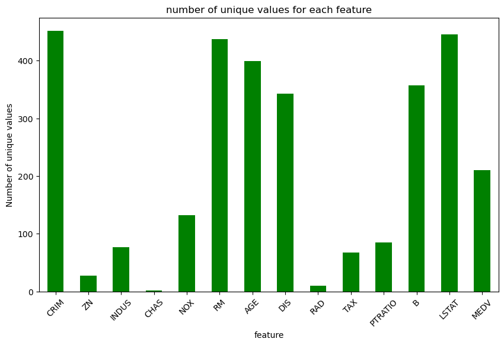

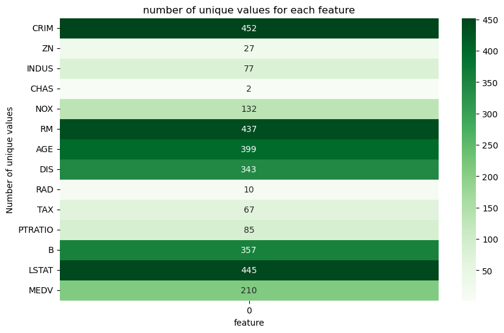

```python
import matplotlib.pyplot as plt
import seaborn as sns

unique_values = df.nunique()
plt.figure(figsize=(10, 6))
unique_values.plot(kind='bar', color='green')
plt.title('number of unique values for each feature')
plt.xlabel('feature')
plt.ylabel('Number of unique values')
plt.xticks(rotation=45)
plt.show()
#-------------------------------------------------------------------------------------
unique_values_matrix = df.apply(lambda x: x.nunique())
plt.figure(figsize=(10, 6))
sns.heatmap(unique_values_matrix.to_frame(), annot=True, cmap='Greens', fmt='d')
plt.title('number of unique values for each feature')
plt.xlabel('feature')
plt.ylabel('Number of unique values')
plt.show()
```

This chart(gragh) helps us understand how many unique values each feature has and can provide useful information for understanding and analyzing our data.

### Q4

To determine which features are most correlated with the result, we can simply use df.corr() Considering the the 'MEDV' column.

```python
corr_array = df.corr(numeric_only = True)
corr_array
```

|  | CRIM | ZN | INDUS | CHAS | NOX | RM | AGE | DIS | RAD | TAX | PTRATIO | B | LSTAT | MEDV |
| --- | --- | --- | --- | --- | --- | --- | --- | --- | --- | --- | --- | --- | --- | --- |
| CRIM | 1.000000 | -0.288969 | 0.586719 | -0.108808 | -0.139448 | -0.185045 | 0.462470 | -0.314674 | -0.151996 | 0.754362 | -0.140015 | -0.076602 | 0.392225 | -0.286245 |
| ZN | -0.288969 | 1.000000 | -0.491587 | 0.027097 | 0.038450 | 0.078721 | -0.488006 | 0.273419 | 0.062767 | -0.256799 | 0.049491 | 0.029200 | -0.390092 | 0.331570 |
| INDUS | 0.586719 | -0.491587 | 1.000000 | -0.278229 | -0.394483 | -0.448809 | 0.700699 | -0.613465 | -0.427834 | 0.748951 | -0.351166 | 0.198492 | 0.465583 | -0.411915 |
| CHAS | -0.108808 | 0.027097 | -0.278229 | 1.000000 | 0.750855 | 0.751928 | -0.394058 | 0.705812 | 0.757421 | -0.461679 | 0.602163 | -0.621240 | 0.052407 | 0.136668 |
| NOX | -0.139448 | 0.038450 | -0.394483 | 0.750855 | 1.000000 | 0.975767 | -0.550065 | 0.923152 | 0.985957 | -0.570346 | 0.775302 | -0.843068 | 0.079688 | -0.332778 |
| RM | -0.185045 | 0.078721 | -0.448809 | 0.751928 | 0.975767 | 1.000000 | -0.595786 | 0.946355 | 0.992620 | -0.610962 | 0.806522 | -0.830466 | 0.029450 | 0.740181 |
| AGE | 0.462470 | -0.488006 | 0.700699 | -0.394058 | -0.550065 | -0.595786 | 1.000000 | -0.749412 | -0.585574 | 0.635697 | -0.477048 | 0.377477 | 0.414354 | -0.299893 |
| DIS | -0.314674 | 0.273419 | -0.613465 | 0.705812 | 0.923152 | 0.946355 | -0.749412 | 1.000000 | 0.947272 | -0.697195 | 0.758289 | -0.752246 | -0.074013 | 0.129355 |
| RAD | -0.151996 | 0.062767 | -0.427834 | 0.757421 | 0.985957 | 0.992620 | -0.585574 | 0.947272 | 1.000000 | -0.586540 | 0.805556 | -0.845427 | 0.056185 | -0.217902 |
| TAX | 0.754362 | -0.256799 | 0.748951 | -0.461679 | -0.570346 | -0.610962 | 0.635697 | -0.697195 | -0.586540 | 1.000000 | -0.485166 | 0.329963 | 0.284030 | -0.345898 |
| PTRATIO | -0.140015 | 0.049491 | -0.351166 | 0.602163 | 0.775302 | 0.806522 | -0.477048 | 0.758289 | 0.805556 | -0.485166 | 1.000000 | -0.671126 | 0.049208 | -0.461214 |
| B | -0.076602 | 0.029200 | 0.198492 | -0.621240 | -0.843068 | -0.830466 | 0.377477 | -0.752246 | -0.845427 | 0.329963 | -0.671126 | 1.000000 | -0.191710 | 0.269605 |
| LSTAT | 0.392225 | -0.390092 | 0.465583 | 0.052407 | 0.079688 | 0.029450 | 0.414354 | -0.074013 | 0.056185 | 0.284030 | 0.049208 | -0.191710 | 1.000000 | -0.706255 |
| MEDV | -0.286245 | 0.331570 | -0.411915 | 0.136668 | -0.332778 | 0.740181 | -0.299893 | 0.129355 | -0.217902 | -0.345898 | -0.461214 | 0.269605 | -0.706255 | 1.000000 |

### Q5

as it has been cleared, the 'RM' and 'LSTAT' are most correlated with the result

### Scatter diagram:

Application: Scatter diagram is used to show the relationship between two features. Each point in the scatter diagram represents a sample in the data, and the x and y axes are the characteristics of the two samples, respectively. By drawing this graph, we can check the linear or non-linear relationship between two feature. What it is: In a scatter plot, each point represents a sample in the data. The x and y axis are the characteristics of two features, respectively. If the points fall in a linear pattern, this indicates a linear relationship between the two features. If the points are randomly scattered, there is no correlation between the two featur es.

### Hexbin :

Application: The hexbin chart is used to examine the distribution of data in two-dimensional space and the relationship between two features. This chart is very suitable for models that deal with large amounts of data. What it is: In the hexbin chart, the data is placed in a hexagonal shape in the chart. Each honey represents the number of samples in that area. The color of each honey indicates the number of samples in that area, so that different colors represent different values. This diagram helps us to know the distribution of samples in two-dimensional space and to see the relationship between two features. Using these two plots, we can examine the relationship between the features and the target column (usually a response variable) and visualize the distribution of the data in two-dimensional space. This information can help us identify the features that best correlate with the target column and train better models.

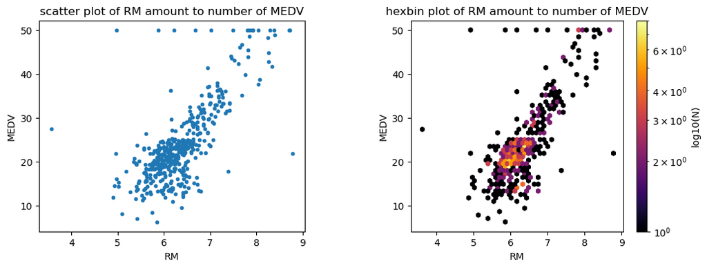

```python
fig, axs = plt.subplots(1, 2, figsize=(12, 4))
axs[0].scatter(df['RM'].to_list(),df['MEDV'].to_list(),s=10)
axs[0].set_title('scatter plot of RM amount to number of MEDV')
axs[0].set_ylabel('MEDV')
axs[0].set_xlabel('RM')

hb =axs[1].hexbin(df['RM'].to_list(),df['MEDV'].to_list(),gridsize=50, bins='log', cmap='inferno')
axs[1].set_title('hexbin plot of RM amount to number of MEDV')
axs[1].set_ylabel('MEDV')
axs[1].set_xlabel('RM')
cb = fig.colorbar(hb, ax=axs[1], label='log10(N)')

plt.subplots_adjust(wspace=0.4)
plt.show()
```

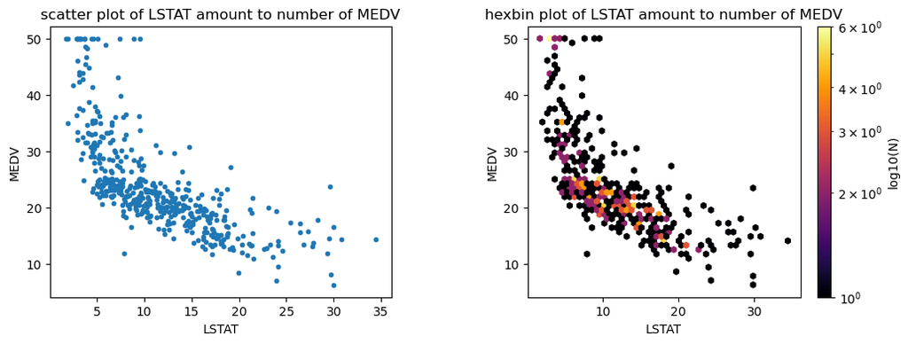

```python
fig, axs = plt.subplots(1, 2, figsize=(12, 4))
axs[0].scatter(df['LSTAT'].to_list(),df['MEDV'].to_list(),s=10)
axs[0].set_title('scatter plot of LSTAT amount to number of MEDV')
axs[0].set_ylabel('MEDV')
axs[0].set_xlabel('LSTAT')

hb =axs[1].hexbin(df['LSTAT'].to_list(),df['MEDV'].to_list(),gridsize=50, bins='log', cmap='inferno')
axs[1].set_title('hexbin plot of LSTAT amount to number of MEDV')
axs[1].set_ylabel('MEDV')
axs[1].set_xlabel('LSTAT')
cb = fig.colorbar(hb, ax=axs[1], label='log10(N)')

plt.subplots_adjust(wspace=0.4)
plt.show()
```

[figure not shown]

```python
import seaborn as sns

plt.figure(figsize=(10, 4))
sns.boxplot(x='MEDV', y='LSTAT', data=df, orient='h', palette='viridis')
plt.title('Boxplot of LSTAT by MEDV')
plt.xlabel('MEDV')
plt.ylabel('LSTAT')
plt.show()
```

[figure not shown]

```python
plt.figure(figsize=(10, 4))
sns.boxplot(x='RM', y='LSTAT', data=df, orient='h', palette='viridis')
plt.title('Boxplot of RM by MEDV')
plt.xlabel('MEDV')
plt.ylabel('RM')
plt.show()
```

## 2. preprocessing of the data set

### Q7

```python
df.fillna(df.mean(numeric_only=True), inplace=True)
df.fillna(df.median(numeric_only=True), inplace=True)
df.fillna(df.mode(numeric_only=True), inplace=True)
```

### Q8

```python
df = pd.DataFrame(df)
df = df.drop(['CRIM', 'ZN', 'CHAS', 'NOX', 'AGE', 'RAD', 'TAX', 'PTRATIO', 'B'], axis=1)
corr_array2 = df.corr(numeric_only = True)
corr_array2
```

|  | INDUS | RM | DIS | LSTAT | MEDV |
| --- | --- | --- | --- | --- | --- |
| INDUS | 1.000000 | -0.448809 | -0.597661 | 0.465583 | -0.369043 |
| RM | -0.448809 | 1.000000 | 0.927119 | 0.029450 | 0.017135 |
| DIS | -0.597661 | 0.927119 | 1.000000 | -0.071474 | 0.045571 |
| LSTAT | 0.465583 | 0.029450 | -0.071474 | 1.000000 | -0.677497 |
| MEDV | -0.369043 | 0.017135 | 0.045571 | -0.677497 | 1.000000 |

### Q9

1. **Numerical features**:
   - These features show independent numerical values that are continuous.
   - Examples of numerical features are average number of rooms (RM) and crime rate (CRIM).
   - Numerical features are used as input for machine learning models.
2. **categorical(Batch) features**:
   - These properties represent values of a given set.
   - Examples of categorical features include the CHAS feature that indicates the presence or absence of access to the Charles River.
   - These features need to be converted to binary domain variables or converted to other domain variables for use in machine learning models.

In the Boston housing dataset, the numerical and categorical characteristics are as follows:

**Numerical features**:

1. CRIM (crime rate)
2. ZN (residential land ratio)
3. INDUS (industrial ratio)
4. NOX (nitrogen oxide concentration)
5. RM (average number of rooms per house)
6. AGE (proportion of units built before 1940)
7. DIS (weighted distances to five Boston employment centers)
8. RAD (Radial Road Access Index)
9. TAX (property tax rate)

```python
from sklearn.preprocessing import StandardScaler, MinMaxScaler
import pandas as pd

def preprocess_df(data_frame, exclude_cols):
    numeric_cols = data_frame.select_dtypes(include="number").copy()
    std_scaler = StandardScaler()
    minmax_scaler = MinMaxScaler()

    data_frame[numeric_cols.columns] = minmax_scaler.fit_transform(numeric_cols)
    data_frame[numeric_cols.columns] = std_scaler.fit_transform(numeric_cols)
    data_frame[numeric_cols.columns] = data_frame[numeric_cols.columns].values
    data_frame[exclude_cols] = numeric_cols[exclude_cols]

preprocess_df(df, exclude_cols=["MEDV"])
df.describe()
```

|  | INDUS | RM | DIS | LSTAT | MEDV |
| --- | --- | --- | --- | --- | --- |
| count | 5.060000e+02 | 5.060000e+02 | 5.060000e+02 | 5.060000e+02 | 506.000000 |
| mean | 2.246775e-16 | -2.808469e-17 | 5.616939e-17 | -6.494585e-17 | 23.750442 |
| std | 1.000990e+00 | 1.000990e+00 | 1.000990e+00 | 1.000990e+00 | 8.324335 |
| min | -1.285180e+00 | -4.456540e-01 | -8.010668e-01 | -1.618734e+00 | 6.300000 |
| 25% | -8.049040e-01 | -3.573785e-01 | -5.895008e-01 | -7.691625e-01 | 19.000000 |
| 50% | -3.134583e-01 | -3.441032e-01 | -3.443840e-01 | -1.910907e-01 | 22.750000 |
| 75% | 1.241856e+00 | -3.210645e-01 | 7.122586e-03 | 5.738951e-01 | 25.000000 |
| max | 2.587747e+00 | 3.100772e+00 | 2.803909e+00 | 3.774952e+00 | 50.000000 |

### Q10

Scaling normalizes data between 0 and 1. It gives equal importance to all features and reduces the influence of outliers. It is most useful when features have different scales. It also helps the convergence of ML algorithms. Standardizing data transforms it to have a mean of 0 and a standard deviation of 1. This type of preprocessing is useful for statistical properties and is commonly used in regression and neural networks. In this project, we need to normalize or standardize the data because our features have different scales.

### Q11

**some examples:**  
Label Encoding: Label encoding assigns a unique integer value to each category in a category attribute. Each category is mapped to a numerical label, allowing the model to understand the ordinal relationship between the categories.  
Frequency Coding: Frequency coding replaces each category with the frequency or proportion of that category in the data set.

### Q12

The choice depends on the amount of data available, but typically, 20 or 30 percent of the data is reserved for testing. For splitting the data into train and test sets, various methods such as random splitting can be considered. If you have time series data, you should consider the order of the data to prevent information loss. One of the most common methods for train-test splitting is using Cross-Validation. In this method, we divide the data into multiple subsets and train the model several times. Each time, we use one of these subsets as the test set and the rest as the training set, and finally, we take the average of these tests.

## Part 3

### Phase 1 - Linear Regression

### Q14

1. **Unsupervised Learning Models**:

In these models, data is used for training without labels. These models aim to discover patterns and relationships in the data.

Example: Clustering  
In clustering, the model seeks to group data based on their similarities without the need for prior labels. For instance, in text clustering, texts are grouped based on common topics.

2. **Semi-Supervised Learning Models**:

These models utilize a combination of labeled and unlabeled data for training. They use labeled data for learning and unlabeled data to improve model performance.

Example: Self-Training  
In self-training, the model is initially trained on a small set of labeled data. It then utilizes its predictions on unlabeled data and adds them as labeled data.

3. **Reinforcement Learning Models**:

In these models, the learning agent makes decisions independently and achieves specific goals through interaction with the environment, receiving feedback.

Example: Autonomous Driving  
In autonomous driving, the learning agent makes decisions like accelerating, braking, and steering based on current environmental conditions (e.g., road conditions and obstacles) and utilizes received feedback (positive or negative) to improve its performance.

### Q15

Regression is one of the important methods in machine learning used to predict a continuous variable based on input variables. In fact, the main goal of regression is to find a relationship that provides the best prediction of the dependent variable based on the independent variables. This relationship is in the form of a mathematical model of a function that maps the input variables to the dependent variable.

The main difference between regression and classification methods is that regression is used for continuous variables such as product prices, individual income, or temperature, while classification methods are typically used for predicting discrete variables such as categorizing images as cats or dogs, detecting spam emails, and so on.

### Q16

Main form of simple linear regression function: $$f(x) = \alpha x + \beta$$

- step 1: Compute RSS of the training data

$$ RSS = \Sigma (y_i - (\hat{\beta} + \hat{\alpha} * x_i) )^2 $$

- step 2: Compute the derivatives of the RSS function in terms of $\alpha$ and $\beta$, and set them equal to 0 to find the desired parameters

$$ \frac{\partial RSS}{\partial \beta} = \Sigma (-f(x_i) + \hat{\beta} + \hat{\alpha} * x_i) = 0$$$$ \to \beta = \hat{y} - \hat{\alpha} \hat{x} \to (1)$$$$ \frac{\partial RSS}{\partial \alpha} = \Sigma (-2 x_i y_i + 2 \hat{\beta} x_i + 2\hat{\alpha} x_i ^ 2) = 0 \to (2)$$$$ (1) , (2) \to \hat{\alpha} = \frac{\Sigma{(x_i - \hat{x})(y_i - \hat{y})}}{\Sigma{(x_i - \hat{x})^2}} $$$$ \hat{\beta} = y - \hat{a} x$$

Based on the above formula, implement the function below to compute the parameters of a simple linear regression

### Q17

I am going to pick the LSTAT feature as the main feature here because it has the highest correlation

```python
def linear_regression(input, output):
    x_mean = np.mean(input)
    y_mean = np.mean(output)
    xy_covariance = np.mean(input * output) - x_mean * y_mean
    x_variance = np.mean(input ** 2) - x_mean ** 2

    alpha = xy_covariance / x_variance
    beta = y_mean - alpha * x_mean

    return alpha, beta
```

Now complete this `get_regression_predictions(...)` function to predict the value of given data based on the calculated intercept and slope

```python
def get_regression_predictions(input, intercept, slope):
    return (input * slope) + intercept
```

Now that we have a model and can make predictions, let's evaluate our model using Root Mean Square Error (RMSE). RMSE is the square root of the mean of the squared differences between the residuals, and the residuals is just a fancy word for the difference between the predicted output and the true output.

Complete the following function to compute the RSME of a simple linear regression model given the input_feature, output, intercept and slope:

```python
def get_root_mean_square_error(predicted_values, actual_values):
    squared_errors = np.power(actual_values - predicted_values, 2)
    sum_of_squared_errors = np.sum(squared_errors)
    squared_error_mean = sum_of_squared_errors
    # squared_error_mean = sum_of_squared_errors / len(actual_values)
    return math.sqrt(squared_error_mean)
```

The RMSE has no bound, thus it becomes challenging to determine whether a particular RMSE value is considered good or bad without any reference point. Instead, we use R2 score. The R2 score is calculated by comparing the sum of the squared differences between the actual and predicted values of the dependent variable to the total sum of squared differences between the actual and mean values of the dependent variable. The R2 score is formulated as below:

$$R^2 = 1 - \frac{SSres}{SStot} = 1 - \frac{\sum_{i=1}^{n} (y_{i,true} - y_{i,pred})^2}{\sum_{i=1}^{n} (y_{i,true} - \bar{y}_{true})^2} $$

Complete the following function to calculate the R2 score of a given input_feature, output, bias, and slope:

```python
def get_r2_score(predicted_values, actual_values):
    residual_sum_of_squares = np.sum(np.power(actual_values - predicted_values, 2))

    total_sum_of_squares = np.sum(np.power(actual_values - np.mean(predicted_values), 2))

    r2_score_val = 1 - (residual_sum_of_squares / total_sum_of_squares)

    return r2_score_val
```

Now calculate the fitness of the model. Remember to provide explanation for the outputs in your code!

### Q18

RSS calculates the total difference between our estimate and the training data. MSE calculates the mean squared error. RMSD calculates the root mean square of MSE and measures the standard deviation of model residuals. The R2 score is a value between 0 and 1. It calculates how well our model fits the data.

### Q19

```python
from sklearn.model_selection import train_test_split
from sklearn.linear_model import LinearRegression
from sklearn.metrics import mean_squared_error, r2_score
import numpy as np
import math
x = df['LSTAT'].to_numpy()
y = df['MEDV'].to_numpy()
x_train,x_test,y_train,y_test = train_test_split(x,y)
alpha,beta = linear_regression(x_train,y_train)
y_pred = get_regression_predictions(x_test,beta,alpha)
print(f"RMSE ERROR: {get_root_mean_square_error(y_pred,y_test)}")
print(f"R2 SCORE: {get_r2_score(y_pred,y_test)}")
# x , y
# designated_feature_list = [] # ToDo

# for feature in designated_feature_list:
#   pass
#   #TO DO
```

```
RMSE ERROR: 62.68538864408193
R2 SCORE: 0.41604415321004695
```

### Q20

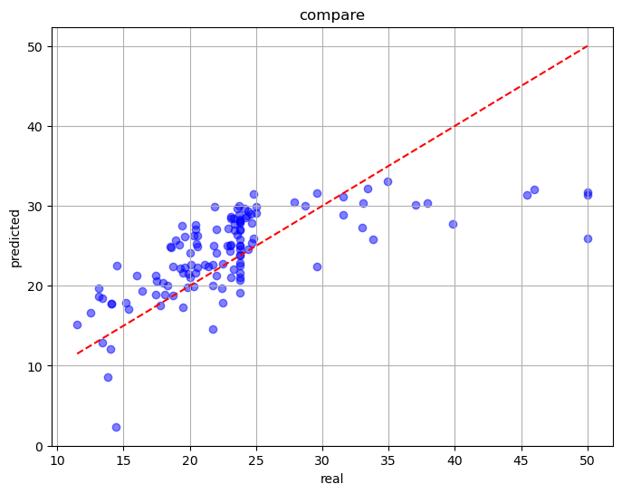

```python
import matplotlib.pyplot as plt

plt.figure(figsize=(8, 6))
plt.scatter(y_test, y_pred, color='blue', alpha=0.5)
plt.plot([y_test.min(), y_test.max()], [y_test.min(), y_test.max()], color='red', linestyle='--')
plt.title('compare')
plt.xlabel('real')
plt.ylabel('predicted')
plt.grid(True)
plt.show()
```

# Ploynomial Regression

To extend the simple linear regression to polynomial regression, we can model the relationship between the independent variable $x$ and the dependent variable $y$ as a polynomial function of degree $n$:

$$f(x) = \beta_0 + \beta_1x + \beta_2x^2 + \ldots + \beta_nx^n$$

The steps to find the parameters $\beta_i$ are similar to those in simple linear regression. We again minimize the RSS function by taking the derivatives with respect to each parameter and setting them to 0.

- Step 1: Compute the RSS function for polynomial regression:

$$ RSS = \Sigma (y_i - (\hat{\beta_0} + \hat{\beta_1}x_i + \hat{\beta_2}x_i^2 + \ldots + \hat{\beta_n}x_i^n))^2 $$

- Step 2: Compute the derivatives of the RSS function with respect to each parameter $\beta_i$ and set them to 0 to find the desired parameters.

$$ \frac{\partial RSS}{\partial \beta_i} = 0, \text{ for } i = 0, 1, 2, \ldots, n$$

Solving these equations will give us the optimal values of $\beta_i$ for the polynomial regression model. The specific form of the equations will depend on the degree of the polynomial and the number of parameters.

The general form for finding the coefficients for polynomial regression can be represented as:

$$ \beta = (X^T X)^{-1} X^T y $$

where:

- $X$ is the design matrix with columns $x^0, x^1, x^2, ..., x^n$
- $x^i$ represents the feature vector of $x$ raised to the power of $i$
- $y$ is the target variable vector
- $\beta$ is the coefficient vector for the polynomial regression

By solving for $\beta$ using the above formula, we can obtain the coefficients for the polynomial regression model.

## classification

### Q21

**The concept of pruning in decision trees:** Pruning in the decision tree means removing some nodes and divisions from the tree, which makes it simpler and reduces overfitting of the model. This process means reducing the size of the decision tree while maintaining its performance.

**Advantages:**

- **Simpler structure**: Simpler and more interpretable decision trees are obtained, which allows for easier interpretation and use.

**Disadvantages:**

- **Chance of losing important information**: If pruning is done too much, important information from the data will be lost and the model will lose its accuracy.

### Q22

1. **Computational efficiency**: Compared to some more complex models, the calculation and construction of the decision tree is done quickly and does not require more complex calculations.
2. **Big data processing**: Decision trees can also be effective for large data sets with a large number of variables.
3. **Resistance to incomplete data**: Decision trees can adapt well to data that contains incomplete or outlier values.

### Q23

Overall, KNN is the easiest algorithm to use without training. Neural networks and logistic regression are both more complex algorithms with different training steps.

### Q24

In this algorithm, for each new point, we find the closest point from the training data set and based on its label, we determine the label of the new point.

**Advantages:**

1. **Simplicity**: It is a very simple algorithm that works well for simple problems and when the data is well separated.
2. **Lack of computational complexity**: The algorithm does not need to store and prepare the model, and its computational cost is very low.

**Disadvantages:**

1. **Sensitivity to noisy data**: This algorithm is very sensitive to noisy data and outliers, and its performance may be affected.

### Q26

```python
from sklearn.model_selection import train_test_split
from sklearn.preprocessing import StandardScaler
from sklearn.tree import DecisionTreeClassifier
from sklearn.neighbors import KNeighborsClassifier
from sklearn.metrics import accuracy_score, classification_report

df['HOUSE_CATEGORY'] = np.where(df['MEDV'] > df['MEDV'].quantile(0.66), 'Luxury',
                                  np.where(df['MEDV'] < df['MEDV'].quantile(0.33), 'Economy', 'Regular'))

X = df.drop(['MEDV', 'HOUSE_CATEGORY'], axis=1)
y = df['HOUSE_CATEGORY']
X_train, X_test, y_train, y_test = train_test_split(X, y, test_size=0.2, random_state=42)

scaler = StandardScaler()
X_train = scaler.fit_transform(X_train)
X_test = scaler.transform(X_test)
dt_model = DecisionTreeClassifier(max_depth=5, min_samples_split=5, random_state=42)
dt_model.fit(X_train, y_train)
y_pred_dt = dt_model.predict(X_test)

print("Decision Tree Classifier Report:")
print(classification_report(y_test, y_pred_dt))
print("Decision Tree Classifier Accuracy:", accuracy_score(y_test, y_pred_dt))

knn_model = KNeighborsClassifier(n_neighbors=5)
knn_model.fit(X_train, y_train)
y_pred_knn = knn_model.predict(X_test)

print("\nK Nearest Neighbors Classifier Report:")
print(classification_report(y_test, y_pred_knn))
print("K Nearest Neighbors Classifier Accuracy:", accuracy_score(y_test, y_pred_knn))
```

```
Decision Tree Classifier Report:
              precision    recall  f1-score   support

     Economy       0.88      0.77      0.82        39
      Luxury       0.90      0.62      0.73        29
     Regular       0.58      0.82      0.68        34

    accuracy                           0.75       102
   macro avg       0.79      0.74      0.75       102
weighted avg       0.79      0.75      0.75       102

Decision Tree Classifier Accuracy: 0.7450980392156863

K Nearest Neighbors Classifier Report:
              precision    recall  f1-score   support

     Economy       0.89      0.85      0.87        39
      Luxury       0.70      0.66      0.68        29
     Regular       0.61      0.68      0.64        34

    accuracy                           0.74       102
   macro avg       0.73      0.73      0.73       102
weighted avg       0.74      0.74      0.74       102

K Nearest Neighbors Classifier Accuracy: 0.7352941176470589
```

### Q27

```python
from sklearn.tree import DecisionTreeClassifier
from sklearn.neighbors import KNeighborsClassifier
from sklearn.metrics import classification_report, accuracy_score
from sklearn.model_selection import GridSearchCV

dt_params = {
    'max_depth': [3, 5, 7, 10],
    'min_samples_split': [2, 5, 10],
    'min_samples_leaf': [1, 2, 4]
}

dt_grid = GridSearchCV(DecisionTreeClassifier(random_state=42), dt_params, cv=5, scoring='accuracy')
dt_grid.fit(X_train, y_train)

print("Best Parameters for Decision Tree:", dt_grid.best_params_)

dt_best = dt_grid.best_estimator_
y_pred_dt_best = dt_best.predict(X_test)
print("\nDecision Tree Classifier Report (Best Parameters):")
print(classification_report(y_test, y_pred_dt_best))
print("Decision Tree Classifier Accuracy (Best Parameters):", accuracy_score(y_test, y_pred_dt_best))

knn_params = {
    'n_neighbors': [3, 5, 7, 10],
    'weights': ['uniform', 'distance']
}

knn_grid = GridSearchCV(KNeighborsClassifier(), knn_params, cv=5, scoring='accuracy')
knn_grid.fit(X_train, y_train)

print("\nBest Parameters for KNN:", knn_grid.best_params_)

knn_best = knn_grid.best_estimator_
y_pred_knn_best = knn_best.predict(X_test)
print("\nK Nearest Neighbors Classifier Report (Best Parameters):")
print(classification_report(y_test, y_pred_knn_best))
print("K Nearest Neighbors Classifier Accuracy (Best Parameters):", accuracy_score(y_test, y_pred_knn_best))
```

```
Best Parameters for Decision Tree: {'max_depth': 5, 'min_samples_leaf': 2, 'min_samples_split': 10}

Decision Tree Classifier Report (Best Parameters):
              precision    recall  f1-score   support

     Economy       0.88      0.77      0.82        39
      Luxury       0.90      0.62      0.73        29
     Regular       0.58      0.82      0.68        34

    accuracy                           0.75       102
   macro avg       0.79      0.74      0.75       102
weighted avg       0.79      0.75      0.75       102

Decision Tree Classifier Accuracy (Best Parameters): 0.7450980392156863

Best Parameters for KNN: {'n_neighbors': 7, 'weights': 'distance'}

K Nearest Neighbors Classifier Report (Best Parameters):
              precision    recall  f1-score   support

     Economy       0.85      0.85      0.85        39
      Luxury       0.74      0.69      0.71        29
     Regular       0.64      0.68      0.66        34

    accuracy                           0.75       102
   macro avg       0.74      0.74      0.74       102
weighted avg       0.75      0.75      0.75       102

K Nearest Neighbors Classifier Accuracy (Best Parameters): 0.7450980392156863
```

### Q28

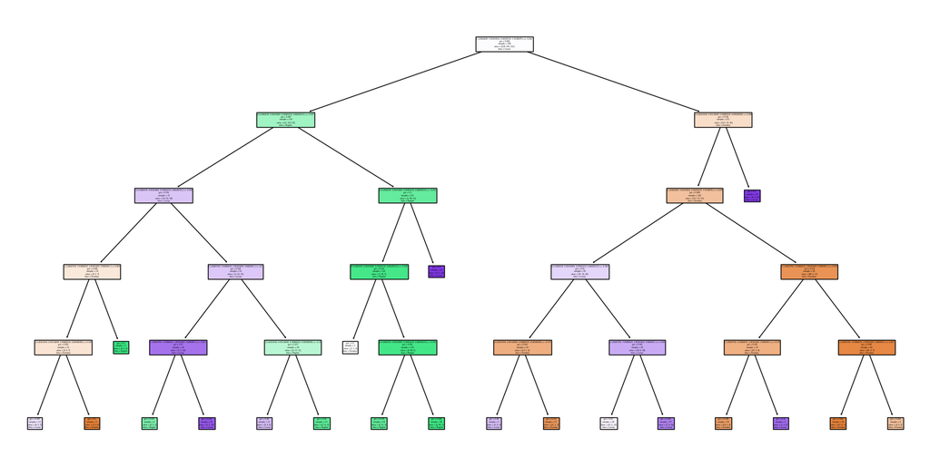

```python
from sklearn.tree import plot_tree
import matplotlib.pyplot as plt

plt.figure(figsize=(20,10))
plot_tree(dt_best, filled=True, feature_names=X_train, class_names=['Economy', 'Regular', 'Luxury'])
plt.show()
```

### Q29

Underfitting occurs when the model is too simple to capture complex patterns in the data, resulting in poor performance in predicting new data. This typically happens due to choosing a very basic model or using a small number of features, preventing the model from learning more complex patterns.

### Q31

**Bagging:**

- Several models are built independently of each other.
- Data are randomly selected with replacement.
- There is no particular order in building the models.
- The mistakes of one model do not affect the oher.

**Boosing:**

- Models are built sequentially.
- The data is weighted based on the performance of previous models.
- Models try to correct the mistakes of previus models.

**Dfferences:**

**How to apply models:**

- In bagging, different models are built independently of each other and after training independently of each other, their resuls are combined.

**Relationship with data:**

- In bagging, data is randomly selected with replacement for each model.

### Q32

In random forests, several independent decision trees are trained simultaneously. Each tree is randomly constructed from a subset of data and features. Then, at each step, as new data comes in, each tree makes its own prediction, and their results are combined to make a final prediction. This combination can be in the form of majority voting (which predicts the highest number of votes) or the average of the values predicted by each tree. Because each tree is trained independently and is made from a random sample of data, this method benefits from increasing flexibility and reducing overfitting.

### Q32

In random forests, bootstrapping is an important process used to build each decision tree. This method employs the resampling with replacement technique.

Bootstrapping steps are as follow:

1. **Backward sampling**: New samples are generated from the existing data set. In this process, each data point may be repeated several times or may not be present in the formation of a new samle.
2. **Decision tree training**: Using the new samples from the previous step, a decision tree is trained. This tree is randomly constructed from the dataset and may use different variables of the samples.
3. **Combination of results**: Finally, by applying the voting or averaging technique on the predictions of each tree, the final result is otained.

Bootstrapping creates more flexibility in the model due to the generation of random and multiple samples. This method prevents overfitting and increases the accuracy and performance of the model in the test data. Additionally, this method can help the model better withstand outliers and noisy data.

### Q33

Bootstrapping is used in random forests to train multiple decision trees by generating random samples from the available data and combine their results. This prevents overfitting and improves model performance. Bootstrapping increases the model's flexibility and resistance to outliers and noise.

### Q34

Yes, the number of decision trees in a random forest has a direct impact on model performance. Usually, as the number of trees increases, the performance of the model improves to a reasonable extent. But after a point, increasing the number of trees can lead to overfitting and reduce the accuracy of the model. The optimal number of decision trees is usually determined empirically, but in general values between 100 and 500 trees usually work well.

### Q35

The use of random forest is usually not appropriate in cases where the data are few and limited or when facing problems with a large number of variables (features). In addition, if decision models alone fail to provide acceptable performance, random forest is recommended. For example, when the original model is overfitting.

### Q36

Using random forest can reduce the variance and make the model more reliable, especially when dealing with data that has high variability and may not be easily covered by a single model.

### Q37

```python
# !pip install xgboost
# does not work
```

```python
# from sklearn.ensemble import RandomForestClassifier
# from sklearn.model_selection import GridSearchCV

# rf_params = {
#     'n_estimators': [100, 200, 300],
#     'max_depth': [None, 10, 20, 30],
#     'min_samples_split': [2, 5, 10],
#     'min_samples_leaf': [1, 2, 4],
#     'max_features': ['auto', 'sqrt', 'log2']
# }

# rf = RandomForestClassifier(random_state=42)

# rf_grid = GridSearchCV(rf, rf_params, cv=5, scoring='accuracy')
# rf_grid.fit(X_train, y_train)

# print("Best Parameters for Random Forest:")
# print(rf_grid.best_params_)
```

## XGBoost

### Q38

XGBoost is a machine learning algorithm based on the gradient descent method. This algorithm gradually optimizes a model using the objective function. Fast performance and high efficiency are its features.

### Q39

Gradient Boosting is a machine learning method that improves the performance of the model by gradually correcting it. While in Decision Tree, only one decision tree is used, but in Boosting Tree, several trees are combined to improve the model..

## Support Vector Machine

### Q40

**1.**

```python
from sklearn.svm import SVC
import numpy as np

svm_rbf = SVC(kernel='rbf', random_state=42)
svm_rbf.fit(X_train, y_train)

svm_linear = SVC(kernel='linear', random_state=42)
svm_linear.fit(X_train, y_train)
```

```
SVC(kernel='linear', random_state=42)
```

**2.**

```python
from sklearn.metrics import confusion_matrix, classification_report

y_pred_rbf = svm_rbf.predict(X_test)

cm_rbf = confusion_matrix(y_test, y_pred_rbf)
print("Confusion Matrix for SVM with RBF Kernel:")
print(cm_rbf)
print("\nClassification Report for SVM with RBF Kernel:")
print(classification_report(y_test, y_pred_rbf))

y_pred_linear = svm_linear.predict(X_test)

cm_linear = confusion_matrix(y_test, y_pred_linear)
print("\nConfusion Matrix for SVM with Linear Kernel:")
print(cm_linear)
print("\nClassification Report for SVM with Linear Kernel:")
print(classification_report(y_test, y_pred_linear))
```

```
Confusion Matrix for SVM with RBF Kernel:
[[33  0  6]
 [ 1 25  3]
 [ 4  6 24]]

Classification Report for SVM with RBF Kernel:
              precision    recall  f1-score   support

     Economy       0.87      0.85      0.86        39
      Luxury       0.81      0.86      0.83        29
     Regular       0.73      0.71      0.72        34

    accuracy                           0.80       102
   macro avg       0.80      0.80      0.80       102
weighted avg       0.80      0.80      0.80       102


Confusion Matrix for SVM with Linear Kernel:
[[33  0  6]
 [ 1 25  3]
 [ 5  6 23]]

Classification Report for SVM with Linear Kernel:
              precision    recall  f1-score   support

     Economy       0.85      0.85      0.85        39
      Luxury       0.81      0.86      0.83        29
     Regular       0.72      0.68      0.70        34

    accuracy                           0.79       102
   macro avg       0.79      0.79      0.79       102
weighted avg       0.79      0.79      0.79       102
```

Analysis:

- **Error Matrix**: Shows correct and incorrect classifications.
- **Accuracy**: Overall performance ratio of correct to total classifications.
- **Recall, Precision, and F1-score**: Measures for each category's performance. Recall measures correctly identified positives over total positives, Precision measures correctly identified positives over all positives, and F1-score combines precision and recall.

Comprehensive analysis of these metrics allows understanding of model performance. For example, high accuracy but low recall or precision may indicate false negatives, highlighting areas for improvement.

**3.**

Here, it seems more appropriate to use the Grid Search method for several reasons:

1. **Multiple parameters and values**: In SVM with RBF kernel, there are multiple parameters such as C and gamma. Grid Search allows us to systematically explore all possible combinations of these parameters to find the optimal values.
2. **Proximity of optimal values**: Optimal values of parameters often tend to be close to each other. Grid Search, by its nature, thoroughly explores parameter space and is likely to quickly identify optimal values.
3. **Limited parameter space**: Since the possible combinations of parameters and their values are finite, Grid Search, although more time-consuming than Random Search, is practical and efficient.

Considering these factors, Grid Search is recommended as the more appropriate method to fine-tune parameters and obtain the best model in this scenario.

**4.**

```python
from sklearn.model_selection import train_test_split, RandomizedSearchCV, GridSearchCV
from sklearn.svm import SVC
from sklearn.metrics import classification_report, confusion_matrix, accuracy_score

X_train, X_test, y_train, y_test = train_test_split(X, y, test_size=0.2, random_state=42)

random_grid = {'C': [0.1, 1, 10, 100, 1000],
               'gamma': [1, 0.1, 0.01, 0.001, 0.0001],
               'kernel': ['rbf', 'linear']}

svm = SVC()

svm_random = RandomizedSearchCV(estimator=svm, param_distributions=random_grid, n_iter=100, cv=3, random_state=42, n_jobs=-1)
svm_random.fit(X_train, y_train)

print("Best Parameters for Random Search:", svm_random.best_params_)

best_svm_random = svm_random.best_estimator_

y_pred_random = best_svm_random.predict(X_test)
print("\nRandom Search SVM Classifier Report:")
print(classification_report(y_test, y_pred_random))
print("Random Search SVM Classifier Accuracy:", accuracy_score(y_test, y_pred_random))

param_grid = {'C': [0.1, 1, 10, 100, 1000],
              'gamma': [1, 0.1, 0.01, 0.001, 0.0001],
              'kernel': ['rbf', 'linear']}

svm_grid = GridSearchCV(estimator=svm, param_grid=param_grid, cv=3, n_jobs=-1)
svm_grid.fit(X_train, y_train)

print("\nBest Parameters for Grid Search:", svm_grid.best_params_)

best_svm_grid = svm_grid.best_estimator_

y_pred_grid = best_svm_grid.predict(X_test)
print("\nGrid Search SVM Classifier Report:")
print(classification_report(y_test, y_pred_grid))
print("Grid Search SVM Classifier Accuracy:", accuracy_score(y_test, y_pred_grid))
```

```
Best Parameters for Random Search: {'kernel': 'rbf', 'gamma': 0.1, 'C': 1000}

Random Search SVM Classifier Report:
              precision    recall  f1-score   support

     Economy       0.81      0.90      0.85        39
      Luxury       0.81      0.59      0.68        29
     Regular       0.61      0.68      0.64        34

    accuracy                           0.74       102
   macro avg       0.74      0.72      0.72       102
weighted avg       0.74      0.74      0.73       102

Random Search SVM Classifier Accuracy: 0.7352941176470589

Best Parameters for Grid Search: {'C': 1000, 'gamma': 0.1, 'kernel': 'rbf'}

Grid Search SVM Classifier Report:
              precision    recall  f1-score   support

     Economy       0.81      0.90      0.85        39
      Luxury       0.81      0.59      0.68        29
     Regular       0.61      0.68      0.64        34

    accuracy                           0.74       102
   macro avg       0.74      0.72      0.72       102
weighted avg       0.74      0.74      0.73       102

Grid Search SVM Classifier Accuracy: 0.7352941176470589
```

## Phase 6: evaluating

```python
# X, y = make_classification(n_samples=1000, n_features=2, n_classes=3, n_clusters_per_class=1, random_state=42)
# X_train, X_test, y_train, y_test = train_test_split(X, y, test_size=0.2, random_state=42)

# svm_rbf = SVC(kernel='rbf')
# svm_rbf.fit(X_train, y_train)
# y_pred_rbf = svm_rbf.predict(X_test)

# conf_matrix_rbf = confusion_matrix(y_test, y_pred_rbf)
# print("Confusion Matrix for SVM with RBF Kernel:")
# print(conf_matrix_rbf)
# print("\nClassification Report for SVM with RBF Kernel:")
# print(classification_report(y_test, y_pred_rbf))

# accuracy_rbf = accuracy_score(y_test, y_pred_rbf)
# print("Accuracy for SVM with RBF Kernel:", accuracy_rbf)
# svm_linear = SVC(kernel='linear')
# svm_linear.fit(X_train, y_train)

# y_pred_linear = svm_linear.predict(X_test)
# conf_matrix_linear = confusion_matrix(y_test, y_pred_linear)
# print("\nConfusion Matrix for SVM with Linear Kernel:")
# print(conf_matrix_linear)

# print("\nClassification Report for SVM with Linear Kernel:")
# print(classification_report(y_test, y_pred_linear))
# accuracy_linear = accuracy_score(y_test, y_pred_linear)
# print("Accuracy for SVM with Linear Kernel:", accuracy_linear)
```